# Workflow for Snowy Owl Population Trends

### 2.1.3 Zero-inflated Poisson distribution

```r
#***********************
#* Zero-inflated Poisson model
#***********************
run <- function(seed, datl, constl){
  library('nimble')
  library('coda')
  library ('nimbleHMC')
  code <- nimbleCode(
    {
      # priors
      for (j in 1:nsite){
        mu[j] ~ dnorm(0, sd=5) # constrain to reasonable values <exp(5) or <148
        beta[j] ~ dnorm(0, sd=5)
        psi[j] ~ dunif(0, 1)
      }
      sigma.time ~ dexp(2)
      # likelihood
      for (t in 1:ntime){
        for (j in 1:nsite){
          y[t,j] ~ dpois(lambda.star[t,j])
          lambda.star[t,j] <- lambda[t,j]*z[t,j]
          z[t,j] ~ dbern(psi[j])
          # abundance
          log(lambda[t,j]) <- mu[j] +
            beta[j]*time[t] +
            eps.time[t]
        } # j
        eps.time[t] ~ dnorm(0, sd=sigma.time)
      } # t

      ###################
      # Assess GOF of the models for counts
      # Step 1: Compute statistic for observed data
      # Step 2: Use discrepancy measure: mean absolute error
      # Step 3: Use test statistic: number of turns
      ###################
      # GOF for model
      for (t in 1:ntime){
        for (j in 1:nsite){
          c.obs[t,j] <- y[t,j] # observed counts
          c.exp[t,j] <- z[t,j]*lambda[t,j] # expected counts adult breeder
          c.rep[t,j] ~ dpois(lambda[t,j]*psi[j]) # expected counts
          # Compute fit statistics, Mean absolute error
          dssm.obs[t,j] <- abs( ( (c.obs[t,j]) - (c.exp[t,j]) ) / (c.obs[t,j]+0.001) )
          dssm.rep[t,j] <- abs( ( (c.rep[t,j]) - (c.exp[t,j]) ) / (c.rep[t,j]+0.001) )
        } } # j # t
      dmape.obs <- sum(dssm.obs[1:ntime,1:nsite])
      dmape.rep <- sum(dssm.rep[1:ntime,1:nsite])
      # variance-mean ratio
      tvm.rep <- sd(c.rep[1:ntime,1:nsite])^2/mean(c.rep[1:ntime,1:nsite])
      tvm.obs <- sd(y[1:ntime,1:nsite])^2/mean(y[1:ntime,1:nsite])
    }
  ) # end model

  params <- c(    "sigma.time",
                  "mu", "beta", "psi",
                  "dssm.obs", "dssm.rep",
                  "dmape.obs", "dmape.rep",
                  "tvm.rep", "tvm.obs"
  )

  # create initial values for missing y data
  y.inits <- array(NA, dim(datl$y))
  y.inits[is.na(datl$y)] <- rpois(sum(is.na(datl$y)), 2)
  inits <- function(){ list (y = y.inits,
                             sigma.time = rexp(1),
                             mu = runif(constl$nsite, -2, 2),
                             beta = runif(constl$nsite, -2, 2),
                             psi = runif(constl$nsite)
  )}

  n.chains=1; n.thin=10; n.iter=20000; n.burnin=10000

  mod <- nimbleModel(code, calculate=T, constants = constl,
                     data = datl, inits = inits(),
                     buildDerivs = TRUE)

  mod$calculate()

  cmod <- compileNimble(mod )
  # Use MCMC rather than HMC
  # because HMC samplers are stuck
  confhmc <- configureMCMC(mod)
  confhmc$setMonitors(params)
  hmc <- buildMCMC(confhmc)
  chmc <- compileNimble(hmc, project=mod, resetFunctions = TRUE)

  post <- runMCMC(chmc,
                  niter = n.iter,
                  nburnin = n.burnin,
                  nchains = n.chains,
                  thin = n.thin,
                  samplesAsCodaMCMC = T)

  return(post)
}

# approximately 15 minute runtime
this_cluster <- makeCluster(4)
post <- parLapply(cl = this_cluster,
                  X = 1:4,
                  fun = run,
                  dat=datl,
                  const=constl)

stopCluster(this_cluster)

zip <- list(as.mcmc(post[[1]]),
             as.mcmc(post[[2]]),
             as.mcmc(post[[3]]),
             as.mcmc(post[[4]]))

# save(zip, post, run,
#      file="C:\\Users\\rolek.brian\\OneDrive - The Peregrine Fund\\Documents\\Projects\\SnowyOwl_HawkMountain\\zip.Rdata")
params_zip <- c( "sigma.time", "psi",
                 "mu", "beta")
MCMCtrace(zip, params_zip, pdf=F,
          ind = TRUE, Rhat = TRUE, n.eff = TRUE)

par(mfrow=c(1,1))
MCMCplot(object = zip, params = params_zip)
```

### 2.1.4 A function to assess goodness-of-fit

```r
# Function for posterior predictive checks
# to assess goodness-of-fit
plot.diag <- function(out, ratio=FALSE, lab=""){
  par(mfrow=c(1,1))
  # plot mean absolute percentage error
  samps <- MCMCpstr(out, "all", type="chains")
  mx <- max(c(samps$dmape.rep, samps$dmape.obs))
  mn <- min(c(samps$dmape.rep, samps$dmape.obs))
  plot(jitter(samps$dmape.obs, amount=300),
       jitter(samps$dmape.rep, amount=300),
       main=paste0("Mean absolute percentage error\n",lab),
       ylab="Discrepancy replicate values",
       xlab="Discrepancy observed values",
       xlim=c(mn,mx), ylim=c(mn,mx),
       pch=16, cex=0.5, col="gray10")
  curve(1*x, from=mn, to=mx, add=T, lty=2, lwd=2, col="blue")
  bp1 <- round(mean(samps$dmape.rep > samps$dmape.obs),2)
  loc <- ifelse(bp1 < 0.5, "topleft", "bottomright")
  legend(loc, legend=bquote(p[B]==.(bp1)), bty="n", cex=2)

  if (ratio==TRUE){
    # plot variance/mean ratio
    hist(samps$tvm.rep, nclass=50,
         xlab="variance/mean ", main=NA, axes=FALSE)
    abline(v=samps$tvm.obs, col="red")
    axis(1); axis(2)
  }
  return(list('Bayesian p-value'=bp1))
}
```

### 2.1.5 Check goodness-of-fit

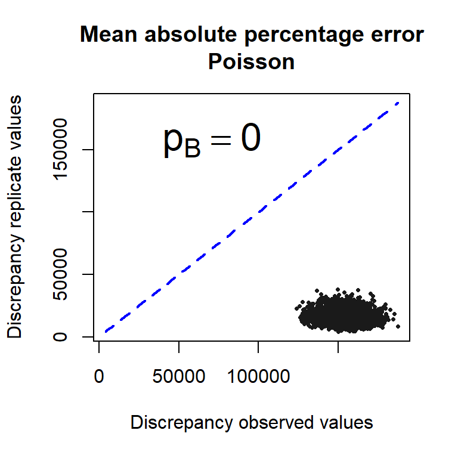

Fig. S3. Posterior predictive check for the Poisson model.

```
## $`Bayesian p-value`
## [1] 0
```

```r
params_pois <-c( "sigma.time",
                 "mu", "beta")
load("C:\\Users\\rolek.brian\\OneDrive - The Peregrine Fund\\Documents\\Projects\\SnowyOwl_HawkMountain\\pois.Rdata")
plot.diag(pois, lab="Poisson") # posterior predictive check
```

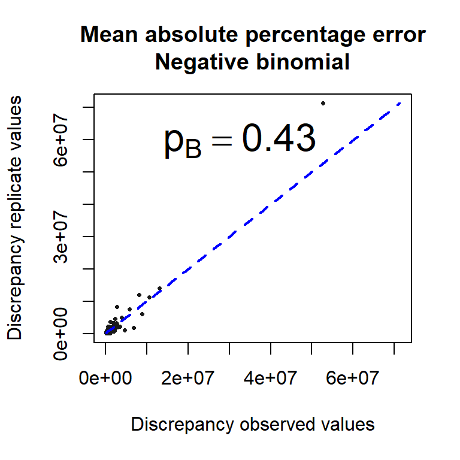

Fig. S4. Posterior predictive check for the negative binomial model.

```
## $`Bayesian p-value`
## [1] 0.43
```

```r
params_nb <-c( "sigma.time",
               "mu", "beta", "r")
load("C:\\Users\\rolek.brian\\OneDrive - The Peregrine Fund\\Documents\\Projects\\SnowyOwl_HawkMountain\\nb.Rdata")
plot.diag(nb, lab="Negative binomial") # posterior predictive check
```

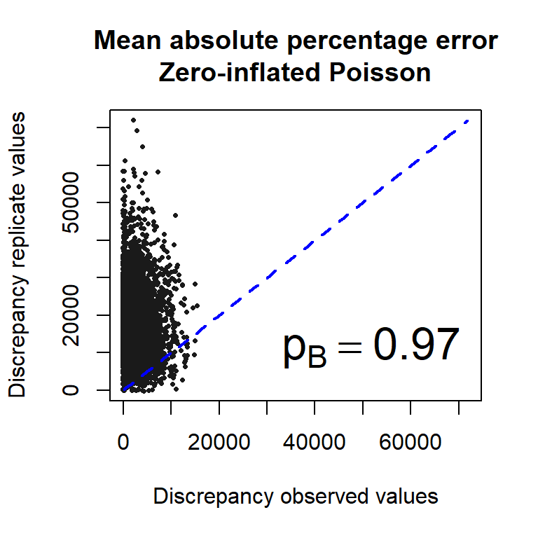

Fig. S5. Posterior predictive check for the zero-inflated Poisson model.

```
## $`Bayesian p-value`
## [1] 0.97
```

```r
# Check for convergence
params_zip <- c( "sigma.time", "psi",
                 "mu", "beta")
load("C:\\Users\\rolek.brian\\OneDrive - The Peregrine Fund\\Documents\\Projects\\SnowyOwl_HawkMountain\\zip.Rdata")

plot.diag(zip, lab="Zero-inflated Poisson") # posterior predictive check
```

## 2.2 Postprocess the best-fitting model (negative binomial)

Load the required libraries, data, and model output.

```r
library("zoo")
library ("HDInterval")
library ("MCMCvis")
library ("ggplot2")
library ("reshape2")
library("gridBase")
library("grid")
library ("gridExtra")
library ("cowplot")
library("bayestestR")
library ("ggdist")
library ("viridis")
options(scipen=999)
load("data/data.Rdata")
# load your negative binomial model here
load("C:\\Users\\rolek.brian\\OneDrive - The Peregrine Fund\\Documents\\Projects\\SnowyOwl_HawkMountain\\nb.Rdata")
# Function for transparency in base R plots
makeTransparent<-function(someColor, alpha=100){
  newColor<-col2rgb(someColor)
  apply(newColor, 2, function(curcoldata){rgb(red=curcoldata[1], green=curcoldata[2],
                                              blue=curcoldata[3],alpha=alpha, maxColorValue=255)})
}
```

### 2.2.1 Print table of parameter estimates

```r
#***********************
#* table with parameter estimates
#***********************
library ("knitr")
nms <- c("Utqiagvik", "Bylot Island Core",
"Karupelv Valley",
"Fennoscandia", "Wrangel")
alll <- MCMCpstr(nb, params = c("mu", "beta", "r","sigma.time"),
                 type="chains")
allm <- do.call(rbind, alll)
tab <- data.frame(
  Median = apply(allm, 1, median),
  LHDI95 = apply(allm, 1, HDInterval::hdi, credMass=0.95)[1,],
  UHDI95 = apply(allm, 1, HDInterval::hdi, credMass=0.95)[2,],
  LHDI80 = apply(allm, 1, HDInterval::hdi, credMass=0.80)[1,],
  UHDI80 = apply(allm, 1, HDInterval::hdi, credMass=0.80)[2,],
  pd = apply(allm, 1, pd)
)
tab$sig95 <- ifelse(tab$LHDI95>0 | tab$UHDI95<0, TRUE, FALSE )
tab$sig80 <- ifelse(tab$LHDI80>0 | tab$UHDI80<0, TRUE, FALSE )
tab$Site <- c(rep(nms, 3), "All sites")
tab$Parameter <- c(rep("mu", 5), rep("beta", 5),
                   rep("r", 5), "sigma.time")
tab <- tab[, c(9, 10, 1:8)]
tab <- tab[order(tab$Site), ]
tab[,c(3:8)] <- round(tab[,c(3:8)],3)

knitr::kable(tab[,1:8], digits=2,
             caption="Table S2. Coefficient estimates from the negative binomial model.",
             row.names=FALSE,
             col.names = c("Site", "Parameter", "Median",
                           "95% Lower HDI", "95% Upper HDI",
                           "85% Lower HDI", "85% Upper HDI",
                           "Prob. direction"))
```

Table S2. Coefficient estimates from the negative binomial model.

| Site | Parameter | Median | 95% Lower HDI | 95% Upper HDI | 85% Lower HDI | 85% Upper HDI | Prob. direction |
| --- | --- | --- | --- | --- | --- | --- | --- |
| All sites | sigma.time | 0.17 | 0.01 | 0.53 | 0.01 | 0.34 | 1.00 |
| Bylot Island Core | mu | 1.43 | 0.45 | 2.78 | 0.70 | 2.17 | 1.00 |
| Bylot Island Core | beta | 0.12 | -1.77 | 2.25 | -1.18 | 1.32 | 0.55 |
| Bylot Island Core | r | 0.15 | 0.04 | 0.28 | 0.07 | 0.22 | 1.00 |
| Fennoscandia | mu | 2.80 | 2.03 | 3.75 | 2.26 | 3.30 | 1.00 |
| Fennoscandia | beta | 0.69 | -0.48 | 1.86 | -0.06 | 1.37 | 0.88 |
| Fennoscandia | r | 0.61 | 0.23 | 1.20 | 0.30 | 0.88 | 1.00 |
| Karupelv Valley | mu | 0.57 | -0.52 | 1.85 | -0.15 | 1.28 | 0.87 |
| Karupelv Valley | beta | -0.57 | -2.18 | 0.95 | -1.52 | 0.37 | 0.78 |
| Karupelv Valley | r | 0.14 | 0.03 | 0.28 | 0.06 | 0.21 | 1.00 |
| Utqiagvik | mu | 2.51 | 1.90 | 3.13 | 2.12 | 2.88 | 1.00 |
| Utqiagvik | beta | -0.73 | -1.86 | 0.43 | -1.43 | 0.04 | 0.90 |
| Utqiagvik | r | 0.46 | 0.22 | 0.78 | 0.28 | 0.64 | 1.00 |
| Wrangel | mu | 4.10 | 3.71 | 4.56 | 3.81 | 4.36 | 1.00 |
| Wrangel | beta | -0.04 | -1.03 | 0.86 | -0.57 | 0.59 | 0.54 |
| Wrangel | r | 1.92 | 0.81 | 3.39 | 1.09 | 2.69 | 1.00 |

```r
#write.csv(tab,
#          file="C:\\Users\\rolek.brian\\OneDrive - The Peregrine Fund\\Documents\\Projects\\SnowyOwl_HawkMountain\\docs\\model_estimates.csv")
```

### 2.2.2 Derive a weighted population growth rate for all sites combined

```r
#***********************
#* Plot an overall trend
#* weighted by abundance
#***********************
# weight by modeled abundance for each year
# weight by data, mean abundance across years
load("C:\\Users\\rolek.brian\\OneDrive - The Peregrine Fund\\Documents\\Projects\\SnowyOwl_HawkMountain\\nb.Rdata")
beta <- MCMCpstr(nb, "beta", type="chains")[[1]]
mu <- MCMCpstr(nb, "mu", type="chains")[[1]]
pred.lam <- array(NA, dim=c(length(constl$time), nrow(mu),  ncol(mu)))

for (i in 1:nrow(mu)){
  for (t in 1:length(constl$time)){
    pred.lam[t,i,] <- mu[i,] +
                      beta[i,]*constl$time[t]
  }}
# set NAs for unsurveyed years
wna <- which(is.na(datl$y), arr.ind=TRUE)
for (i in 1:nrow(wna)){
  pred.lam[wna[i,1],wna[i,2], ] <- NA
}

wmns <- as.matrix(datl$y+1)
wmns <- ifelse(is.na(wmns), 0, wmns)
zo <- ifelse(is.na(datl$y), 0, 1)
wts2 <- array(NA, dim(zo))

for (t in 1:nrow(zo)){
  mns <- wmns[t,]*zo[t,] # impute zeroes for unmonitored years
  wts2[t,1:5] <- unlist(mns/sum(mns, na.rm=T)) # calculate proportions
}

lam.post <- array (NA, dim(pred.lam))
# calculate lambda (population growth rate)
for (t in 2:nrow(pred.lam)){
  for (j in 1:ncol(pred.lam)){
    lam.post[t,j,] <- exp(pred.lam[t,j,]) / exp(pred.lam[t-1,j,])
  }}
# calculate a weighted mean (wm)
# of population growth rate
wm.post.lam <- array (NA, c(nrow(pred.lam),dim(pred.lam)[[3]]), dimnames=list(Year=1988:2020, Iter=1:4000))
for (t in 1:nrow(pred.lam)){
  for (k in 1:dim(pred.lam)[[3]]){
    wm.post.lam[t,k] <- weighted.mean(x=lam.post[t,,k], w=wts2[t,], na.rm=T)
  }}
lam.post.long <- melt(wm.post.lam)

# calculate overall average pop growth rate
av.post <- apply(wm.post.lam, 2, mean, na.rm=T)
median(av.post, na.rm=T)
```

```
## [1] 0.9839614
```

```r
HDInterval::hdi(av.post, credMass = 0.95, na.rm=T)
```

```
##     lower     upper
## 0.9480951 1.0230132
## attr(,"credMass")
## [1] 0.95
```

```r
HDInterval::hdi(av.post, credMass = 0.80, na.rm=T)
```

```
##     lower     upper
## 0.9598772 1.0086814
## attr(,"credMass")
## [1] 0.8
```

```r
pd(av.post, null=1, na.rm=T)
```

```
## Probability of Direction: 0.79
```

```r
# calculate pop growth rates for each year
wm.df <- data.frame(
  year= 1988:2020,
  m= apply(wm.post.lam, 1, median, na.rm=T),
  lci= apply(wm.post.lam, 1, HDInterval::hdi)[1,],
  uci= apply(wm.post.lam, 1, HDInterval::hdi)[2,],
  lci80 = apply(wm.post.lam, 1, HDInterval::hdi, credMass=.8)[1,],
  uci80 = apply(wm.post.lam, 1, HDInterval::hdi, credMass=.8)[2,],
  pd = apply(wm.post.lam, 1, pd, null=1)
)
knitr::kable(wm.df, digits=c(0,3,3,3,3,3,2),
             row.names=FALSE,
             col.names = c("Year", "Median", "95% Lower HDI", "95% Upper HDI",
                           "85% Lower HDI", "85% Upper HDI", "Prob. direction"),
             caption="Table S3. Population growth rates for each year.")
```

Table S3. Population growth rates for each year.

| Year | Median | 95% Lower HDI | 95% Upper HDI | 85% Lower HDI | 85% Upper HDI | Prob. direction |
| --- | --- | --- | --- | --- | --- | --- |
| 1988 | NA | NA | NA | NA | NA | 1.00 |
| 1989 | 1.020 | 0.962 | 1.084 | 0.980 | 1.055 | 0.76 |
| 1990 | 0.965 | 0.871 | 1.060 | 0.909 | 1.023 | 0.78 |
| 1991 | 0.997 | 0.939 | 1.055 | 0.960 | 1.031 | 0.54 |
| 1992 | 0.997 | 0.939 | 1.055 | 0.960 | 1.031 | 0.54 |
| 1993 | 0.989 | 0.942 | 1.039 | 0.960 | 1.019 | 0.69 |
| 1994 | 0.993 | 0.942 | 1.044 | 0.962 | 1.025 | 0.62 |
| 1995 | 0.981 | 0.936 | 1.023 | 0.953 | 1.009 | 0.80 |
| 1996 | 0.971 | 0.918 | 1.025 | 0.939 | 1.008 | 0.86 |
| 1997 | 1.004 | 0.953 | 1.048 | 0.975 | 1.035 | 0.56 |
| 1998 | 0.967 | 0.878 | 1.045 | 0.914 | 1.014 | 0.79 |
| 1999 | 0.988 | 0.940 | 1.033 | 0.961 | 1.018 | 0.71 |
| 2000 | 0.989 | 0.947 | 1.034 | 0.965 | 1.020 | 0.68 |
| 2001 | 0.997 | 0.944 | 1.058 | 0.960 | 1.030 | 0.55 |
| 2002 | 0.993 | 0.941 | 1.045 | 0.960 | 1.024 | 0.60 |
| 2003 | 0.992 | 0.946 | 1.037 | 0.964 | 1.021 | 0.64 |
| 2004 | 1.001 | 0.946 | 1.056 | 0.968 | 1.038 | 0.52 |
| 2005 | 0.972 | 0.926 | 1.016 | 0.942 | 0.998 | 0.89 |
| 2006 | 0.978 | 0.934 | 1.020 | 0.949 | 1.005 | 0.84 |
| 2007 | 1.006 | 0.961 | 1.054 | 0.978 | 1.036 | 0.61 |
| 2008 | 0.979 | 0.938 | 1.023 | 0.949 | 1.004 | 0.83 |
| 2009 | 0.997 | 0.940 | 1.055 | 0.960 | 1.031 | 0.55 |
| 2010 | 0.998 | 0.945 | 1.051 | 0.965 | 1.031 | 0.54 |
| 2011 | 0.962 | 0.909 | 1.016 | 0.929 | 0.997 | 0.91 |
| 2012 | 0.961 | 0.911 | 1.019 | 0.928 | 0.996 | 0.92 |
| 2013 | 0.976 | 0.921 | 1.036 | 0.936 | 1.011 | 0.78 |
| 2014 | 0.979 | 0.916 | 1.054 | 0.933 | 1.021 | 0.73 |
| 2015 | 0.964 | 0.906 | 1.017 | 0.927 | 0.998 | 0.90 |
| 2016 | 0.962 | 0.904 | 1.019 | 0.922 | 0.996 | 0.90 |
| 2017 | 0.976 | 0.921 | 1.036 | 0.936 | 1.011 | 0.78 |
| 2018 | 0.962 | 0.904 | 1.019 | 0.922 | 0.996 | 0.90 |
| 2019 | 0.979 | 0.915 | 1.049 | 0.937 | 1.022 | 0.74 |
| 2020 | 0.985 | 0.917 | 1.060 | 0.939 | 1.030 | 0.67 |

```r
c3 <- makeTransparent("gray40", alpha=10)
c4 <- makeTransparent(4, alpha=180)

rownames(wts2) <- rownames(datl$y) <- 1988:2020
colnames(wts2) <- colnames(datl$y)
names(dimnames(datl$y)) <- c("Year", "Site")
all.df <- melt(as.matrix(datl$y), value.name="Count")
all.df$weights <- melt(as.matrix(wts2), value.name="weights")$weights
colnames(all.df) <- c("Year", "Site", "Count", "Weights")
labels <- c("Utqiagvik", "Bylot Island", "Karupelv Valley",
            "Fennoscandia", "Wrangel Island")

sl <- all.df[!is.na(all.df$Count),]

p1 <- ggplot()  + theme_minimal() +
  coord_cartesian(clip = "off") +
  geom_line(data=all.df,aes(x=Year,y=Site,color=Weights), linewidth=2)+
  geom_point(data=sl,aes(x=Year,y=Site),shape="I", size=4)+
  xlab("Year")+ylab("Site")+scale_color_viridis_c()+
  scale_y_discrete(labels=labels)+
  labs(color='Weight') +
  xlim(1988, 2020) + theme(legend.position = "top") +
  annotate(geom = "text", x = 1990, y = 6, label = "A", size=6)

p2 <- ggplot() + theme_minimal() +
      geom_line(data=lam.post.long, aes(x=Year, y=value, group=Iter),
                color="gray40", linewidth=0.5, alpha=0.05 ) +
      geom_hline(yintercept=1, lwd=2, color="black", linetype="dashed") +
      geom_line(data=wm.df, aes(x=year, y=lci), color="deepskyblue3", linewidth=0.5 ) +
      geom_line(data=wm.df, aes(x=year, y=uci ), color="deepskyblue3", linewidth=0.5) +
      geom_line(data=wm.df, aes(x=year, y=lci80), color="deepskyblue3", linewidth=1 ) +
      geom_line(data=wm.df, aes(x=year, y=uci80), color="deepskyblue3", linewidth=1 ) +
      geom_line(data=wm.df, aes(x=year, y=m), color="deepskyblue3", linewidth=2 ) +
      xlab("Year") +
      ylab( expression(paste("Population growth (", lambda,")")) )+
      xlim(1988, 2020) +
      annotate(geom = "text", x = 1990, y = 1.2, label = "B", size=6)+
      coord_cartesian(xlim=c(1988, 2020), ylim=c(0.85, 1.15))

ap12 <- align_plots(p1, p2, align="v", axis="l")
p12 <- plot_grid(ap12[[1]], ap12[[2]], nrow = 2, align="v")
```

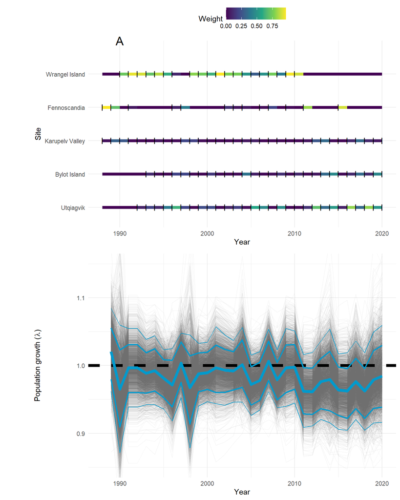

Fig. S6. Population growth rates of Snowy Owl.

```r
p12
```

```r
# ggsave(filename="C:\\Users\\rolek.brian\\OneDrive - The Peregrine Fund\\Documents\\Projects\\SnowyOwl_HawkMountain\\docs\\figs\\pop-growth-rate_year.tiff",
#        plot=p12,
#        device="tiff",
#        width=6,
#        height=8,
#        dpi=300)
```

### 2.2.3 Derive percent change for IUCN Red List Criteria

#### 2.2.3.1 Calculate percent change with 8-year and 10.7-year generation time

```r
#***********
#* Calculate proportion of base year
#* or percent change
#* Short generation time
#* 8-year generations
#*************
# calculate lambda from 1996
startyr <- 2020-(3*8) # 3 generations of 8 years
dnames <- list(year=1988:2020,
               site=nms,
               Iter=1:4000)

iucn <- array(NA, dim=dim(wm.post.lam), dimnames=dimnames(wm.post.lam))
# abund1996 <- apply(pred.lam[9,,], c(2), mean, na.rm=T)
iucn[9,] <- 1 #abund1996/mean(abund1996)
for (t in 10:nrow(wm.post.lam)){
iucn[t,] <- iucn[(t-1),] * wm.post.lam[t,]
}
for (t in 8:1){
  iucn[t,] <- iucn[(t+1),] / wm.post.lam[(t+1),]
}

# convert to percent change
iucn <- (iucn-1) * 100
iucn.post <- melt(iucn)

i.df <- data.frame(
  year = 1988:2020,
  m = apply(iucn, 1, median, na.rm=T),
  lci95 = apply(iucn, 1, HDInterval::hdi)[1,],
  uci95 = apply(iucn, 1, HDInterval::hdi)[2,],
  lci80 = apply(iucn, 1, HDInterval::hdi, credMass=0.8)[1,],
  uci80 = apply(iucn, 1, HDInterval::hdi, credMass=0.8)[2,],
  pd = apply(iucn, 1, pd)
)
knitr::kable(i.df, digits=c(0,1,1,1,1,1,2),
             row.names=FALSE,
             col.names = c("Year", "Median", "95% Lower HDI", "95% Upper HDI",
                           "85% Lower HDI", "85% Upper HDI", "Prob. direction"),
             caption="Table S4. Percent change since 1996.")
```

Table S4. Percent change since 1996.

| Year | Median | 95% Lower HDI | 95% Upper HDI | 85% Lower HDI | 85% Upper HDI | Prob. direction |
| --- | --- | --- | --- | --- | --- | --- |
| 1988 | 9.1 | -24.2 | 44.3 | -12.4 | 30.0 | 0.71 |
| 1989 | 11.4 | -18.3 | 47.7 | -10.1 | 30.6 | 0.76 |
| 1990 | 7.5 | -22.4 | 36.6 | -10.6 | 25.6 | 0.71 |
| 1991 | 7.3 | -16.2 | 31.0 | -7.9 | 21.4 | 0.74 |
| 1992 | 6.9 | -11.3 | 25.4 | -4.7 | 18.3 | 0.78 |
| 1993 | 5.8 | -6.8 | 19.7 | -3.7 | 13.4 | 0.81 |
| 1994 | 4.9 | -4.4 | 14.4 | -1.3 | 10.8 | 0.86 |
| 1995 | 2.9 | -2.7 | 8.6 | -0.8 | 6.5 | 0.86 |
| 1996 | 0.0 | 0.0 | 0.0 | 0.0 | 0.0 | 0.00 |
| 1997 | 0.4 | -4.7 | 4.8 | -2.5 | 3.5 | 0.56 |
| 1998 | -3.0 | -13.5 | 8.7 | -10.1 | 4.2 | 0.69 |
| 1999 | -4.1 | -15.3 | 9.4 | -11.4 | 4.4 | 0.73 |
| 2000 | -5.1 | -18.2 | 11.6 | -14.6 | 4.5 | 0.74 |
| 2001 | -5.3 | -21.0 | 15.5 | -16.3 | 7.0 | 0.71 |
| 2002 | -6.0 | -27.3 | 17.0 | -20.0 | 7.8 | 0.69 |
| 2003 | -6.8 | -30.4 | 21.5 | -23.1 | 9.2 | 0.69 |
| 2004 | -6.5 | -32.4 | 27.8 | -24.4 | 12.7 | 0.66 |
| 2005 | -9.2 | -37.5 | 26.6 | -28.3 | 11.4 | 0.71 |
| 2006 | -11.5 | -41.2 | 27.6 | -32.7 | 10.3 | 0.73 |
| 2007 | -10.8 | -44.1 | 32.7 | -33.5 | 14.3 | 0.70 |
| 2008 | -12.8 | -46.7 | 34.4 | -37.6 | 13.1 | 0.72 |
| 2009 | -12.9 | -52.4 | 37.6 | -41.4 | 14.4 | 0.70 |
| 2010 | -13.2 | -55.9 | 42.5 | -43.8 | 16.7 | 0.69 |
| 2011 | -16.4 | -56.0 | 43.4 | -45.2 | 16.2 | 0.73 |
| 2012 | -19.7 | -59.3 | 41.1 | -48.8 | 13.3 | 0.76 |
| 2013 | -21.5 | -64.5 | 40.0 | -52.2 | 11.7 | 0.77 |
| 2014 | -23.2 | -66.0 | 42.8 | -55.6 | 11.0 | 0.77 |
| 2015 | -26.3 | -69.3 | 41.9 | -60.6 | 7.2 | 0.79 |
| 2016 | -28.8 | -71.6 | 42.3 | -63.8 | 4.9 | 0.81 |
| 2017 | -30.5 | -74.3 | 44.3 | -65.1 | 5.7 | 0.80 |
| 2018 | -33.1 | -77.7 | 42.8 | -70.0 | 1.3 | 0.82 |
| 2019 | -34.7 | -78.4 | 47.4 | -73.4 | 0.4 | 0.82 |
| 2020 | -35.6 | -81.7 | 50.1 | -74.9 | 1.1 | 0.81 |

```r
p3 <- ggplot() + theme_minimal() +
  geom_rect(aes(xmin=1986, xmax=2022, ymin=-20, ymax=300), color="green4", fill="green4") +
  geom_rect(aes(xmin=1986, xmax=2022, ymin=-30, ymax=-20), color="green3", fill="green3") +
  geom_rect(aes(xmin=1986, xmax=2022, ymin=-50, ymax=-30), color="yellow", fill="yellow") +
  geom_rect(aes(xmin=1986, xmax=2022, ymin=-80, ymax=-50), color="orange", fill="orange") +
  geom_rect(aes(xmin=1986, xmax=2022, ymin=-100, ymax=-80), color="red", fill="red") +
  geom_line(data=iucn.post, aes(x=Year, y=value, group=Iter),
            color="gray40", size=0.5, alpha=0.05 ) +
  geom_hline(yintercept=1, lwd=2, color="black", linetype="dashed") +
  geom_line(data=i.df, aes(x=year, y=lci95), color="black", size=0.5 ) +
  geom_line(data=i.df, aes(x=year, y=uci95 ), color="black", size=0.5) +
  geom_line(data=i.df, aes(x=year, y=lci80), color="black", size=1 ) +
  geom_line(data=i.df, aes(x=year, y=uci80), color="black", size=1 ) +
  geom_line(data=i.df, aes(x=year, y=m), color="black", size=2 ) +
  annotate(geom = "text", x = 1995, y = 25, label = "Least concern", size=4, color="black") +
  annotate(geom = "text", x = 1995, y = -25, label = "Near threatened", size=4, color="black") +
  annotate(geom = "text", x = 1995, y = -40, label = "Vulnerable", size=4, color="black") +
  annotate(geom = "text", x = 1995, y = -70, label = "Endangered", size=4, color="black") +
  annotate(geom = "text", x = 1995, y = -90, label = "Critically endangered", size=4, color="black") +
  xlab("") +
  ylab( "Percent change")+
  coord_cartesian(xlim=c(1988, 2020), ylim=c(-100, 60)) +
  annotate(geom = "text", x = 1995, y = 55, label = "A", size=8) +
  theme(axis.text= element_text(size=12),
        axis.title=element_text(size=14),
        axis.ticks = element_line(color = "black"),
        plot.title = element_text(size=22)) +
  labs(title="8-year generation time")

iucn2020 <- iucn.post[iucn.post$Year==2020, ]
i.df2020 <- i.df[i.df$year==2020,]

p4 <- ggplot() + theme_minimal() +
  geom_rect(aes(ymin=0, ymax=2, xmin=-20, xmax=300), color="green4", fill="green4") +
  geom_rect(aes(ymin=0, ymax=2, xmin=-30, xmax=-20), color="green3", fill="green3") +
  geom_rect(aes(ymin=0, ymax=2, xmin=-50, xmax=-30), color="yellow", fill="yellow") +
  geom_rect(aes(ymin=0, ymax=2, xmin=-80, xmax=-50), color="orange", fill="orange") +
  geom_rect(aes(ymin=0, ymax=2, xmin=-100, xmax=-80), color="red", fill="red") +
  stat_halfeye(data=iucn2020, aes(x = value, y=0), alpha=0.65,
               slab_color="gray20", slab_fill="gray40",
                     point_interval="median_hdi", .width = c(0.80, 0.95),
                     point_size=5) +
  scale_size_continuous(range = c(7, 15)) +
  geom_vline(xintercept=0, lwd=2, color="black", linetype="dashed") +
  xlab("") + ylab("") +
  annotate(geom = "text", x = 55, y = 0.25, label = "C", size=8) +
  theme(axis.text= element_text(size=12),
        axis.title=element_text(size=14),
        axis.ticks = element_line(color = "black")) +
  coord_flip(xlim=c(-100, 60), ylim=c(0, 1), clip="on")

# calculate proportion of distribution in each category and mode
cuttab <- table(cut(iucn2020$value, breaks=c(-100,-80, -50, -30, -20, 300)))
prop <- cuttab/sum(cuttab)

df.iucn <- data.frame(IUCN.criteria=rev( c('Least concern', 'Near threatened', 'Vulnerable', 'Endangered', 'Critically endangered')),
                      Proportion.within=prop,
                      Proportion.within.and.worse= cumsum(prop)
)
df.iucn <- df.iucn[nrow(df.iucn):1,]
knitr::kable(df.iucn, digits=c(0, 0, 2, 2),
             row.names=FALSE,
             col.names = c("IUCN Category", "A2 Criteria", "Prop within", "Prop within and worse"),
             caption="Table S5. Percent change over three generations.")
```

Table S5. Percent change over three generations.

| IUCN Category | A2 Criteria | Prop within | Prop within and worse |
| --- | --- | --- | --- |
| Least concern | (-20,300] | 0.33 | 1.00 |
| Near threatened | (-30,-20] | 0.11 | 0.67 |
| Vulnerable | (-50,-30] | 0.28 | 0.57 |
| Endangered | (-80,-50] | 0.28 | 0.29 |
| Critically endangered | (-100,-80] | 0.01 | 0.01 |

```r
# write.csv(df.iucn,
#           "C:\\Users\\rolek.brian\\OneDrive - The Peregrine Fund\\Documents\\Projects\\SnowyOwl_HawkMountain\\docs\\IUCN.csv")

# calculate the mode
dens <- density(iucn2020$value)
# mode
dens$x[dens$y==max(dens$y)]
```

```
## [1] -45.02996
```

```r
# median
median(iucn2020$value)
```

```
## [1] -35.60979
```

```r
# mean
mean(iucn2020$value)
```

```
## [1] -26.587
```

```r
#***********
#* Calculate proportion of base year
#* or percent change
#* Longer generation time
#* 10.7 yr generations
#*************
# calculate lambda from 1998
max.gen.time <- (2020-1988)/3
startyr <- 1988 # 3 generations of 8 years
dnames <- list(year=1988:2020,
               site=nms,
               Iter=1:4000)

iucn <- array(NA, dim=dim(wm.post.lam), dimnames=dimnames(wm.post.lam))
# abund1996 <- apply(pred.lam[9,,], c(2), mean, na.rm=T)
iucn[1,] <- 1 #abund1996/mean(abund1996)
for (t in 2:nrow(wm.post.lam)){
  iucn[t,] <- iucn[(t-1),] * wm.post.lam[t,]
}

# convert to percent change
iucn <- (iucn-1) * 100
iucn.post <- melt(iucn)

i.df <- data.frame(
  year = 1988:2020,
  m = apply(iucn, 1, median, na.rm=T),
  lci95 = apply(iucn, 1, HDInterval::hdi)[1,],
  uci95 = apply(iucn, 1, HDInterval::hdi)[2,],
  lci80 = apply(iucn, 1, HDInterval::hdi, credMass=0.8)[1,],
  uci80 = apply(iucn, 1, HDInterval::hdi, credMass=0.8)[2,],
  pd = apply(iucn, 1, pd)
)
knitr::kable(i.df, digits=c(0,1,1,1,1,1,2),
             row.names=FALSE,
             col.names = c("Year", "Median", "95% Lower HDI", "95% Upper HDI",
                           "85% Lower HDI", "85% Upper HDI", "Prob. direction"),
             caption="Table S5. Percent change since 1996.")
```

| Year | Median | 95% Lower HDI | 95% Upper HDI | 85% Lower HDI | 85% Upper HDI | Prob. direction |
| --- | --- | --- | --- | --- | --- | --- |
| 1988 | 0.0 | 0.0 | 0.0 | 0.0 | 0.0 | 0.00 |
| 1989 | 2.0 | -3.8 | 8.4 | -2.0 | 5.5 | 0.76 |
| 1990 | -1.6 | -15.5 | 11.9 | -9.6 | 6.9 | 0.60 |
| 1991 | -1.7 | -16.2 | 13.6 | -10.9 | 7.2 | 0.60 |
| 1992 | -2.0 | -18.8 | 17.1 | -12.4 | 10.1 | 0.59 |
| 1993 | -3.1 | -21.9 | 19.7 | -16.3 | 10.0 | 0.62 |
| 1994 | -3.6 | -27.6 | 22.4 | -19.0 | 12.2 | 0.62 |
| 1995 | -5.5 | -31.6 | 23.9 | -22.9 | 11.6 | 0.65 |
| 1996 | -8.3 | -34.4 | 22.9 | -26.5 | 9.4 | 0.71 |
| 1997 | -7.9 | -35.4 | 26.4 | -28.1 | 10.9 | 0.69 |
| 1998 | -10.8 | -40.2 | 29.1 | -32.6 | 10.6 | 0.73 |
| 1999 | -11.9 | -44.9 | 30.1 | -37.0 | 9.9 | 0.73 |
| 2000 | -12.8 | -48.2 | 32.2 | -37.6 | 12.6 | 0.73 |
| 2001 | -13.1 | -50.8 | 37.3 | -38.8 | 15.7 | 0.71 |
| 2002 | -13.8 | -53.3 | 42.3 | -42.2 | 16.2 | 0.71 |
| 2003 | -14.5 | -56.1 | 46.2 | -44.9 | 17.3 | 0.70 |
| 2004 | -14.5 | -62.4 | 46.5 | -49.4 | 16.6 | 0.69 |
| 2005 | -17.0 | -63.7 | 47.9 | -48.8 | 18.8 | 0.71 |
| 2006 | -18.8 | -64.7 | 50.2 | -55.1 | 14.7 | 0.72 |
| 2007 | -18.1 | -66.6 | 56.0 | -54.4 | 19.5 | 0.71 |
| 2008 | -19.9 | -70.1 | 55.9 | -57.5 | 18.2 | 0.72 |
| 2009 | -20.2 | -70.4 | 63.5 | -60.0 | 20.2 | 0.71 |
| 2010 | -20.5 | -72.8 | 69.5 | -62.0 | 22.6 | 0.70 |
| 2011 | -23.5 | -75.1 | 66.2 | -67.5 | 16.4 | 0.72 |
| 2012 | -26.4 | -76.8 | 63.6 | -67.6 | 15.8 | 0.75 |
| 2013 | -28.1 | -77.9 | 66.9 | -70.8 | 13.0 | 0.75 |
| 2014 | -29.6 | -80.0 | 67.6 | -71.6 | 13.2 | 0.76 |
| 2015 | -32.0 | -82.4 | 65.4 | -77.0 | 7.5 | 0.77 |
| 2016 | -34.6 | -82.6 | 66.5 | -78.0 | 6.0 | 0.79 |
| 2017 | -36.2 | -84.4 | 68.6 | -80.1 | 4.7 | 0.79 |
| 2018 | -38.9 | -85.8 | 66.8 | -81.7 | 2.7 | 0.80 |
| 2019 | -40.2 | -87.6 | 68.7 | -82.1 | 3.8 | 0.80 |
| 2020 | -41.0 | -91.9 | 69.7 | -84.2 | 3.5 | 0.80 |

```r
p5 <- ggplot() + theme_minimal() +
  geom_rect(aes(xmin=1986, xmax=2022, ymin=-20, ymax=300), color="green4", fill="green4") +
  geom_rect(aes(xmin=1986, xmax=2022, ymin=-30, ymax=-20), color="green3", fill="green3") +
  geom_rect(aes(xmin=1986, xmax=2022, ymin=-50, ymax=-30), color="yellow", fill="yellow") +
  geom_rect(aes(xmin=1986, xmax=2022, ymin=-80, ymax=-50), color="orange", fill="orange") +
  geom_rect(aes(xmin=1986, xmax=2022, ymin=-100, ymax=-80), color="red", fill="red") +
  geom_line(data=iucn.post, aes(x=Year, y=value, group=Iter),
            color="gray40", size=0.5, alpha=0.05 ) +
  geom_hline(yintercept=1, lwd=2, color="black", linetype="dashed") +
  geom_line(data=i.df, aes(x=year, y=lci95), color="black", size=0.5 ) +
  geom_line(data=i.df, aes(x=year, y=uci95 ), color="black", size=0.5) +
  geom_line(data=i.df, aes(x=year, y=lci80), color="black", size=1 ) +
  geom_line(data=i.df, aes(x=year, y=uci80), color="black", size=1 ) +
  geom_line(data=i.df, aes(x=year, y=m), color="black", size=2 ) +
  annotate(geom = "text", x = 1995, y = 25, label = "Least concern", size=4, color="black") +
  annotate(geom = "text", x = 1995, y = -25, label = "Near threatened", size=4, color="black") +
  annotate(geom = "text", x = 1995, y = -40, label = "Vulnerable", size=4, color="black") +
  annotate(geom = "text", x = 1995, y = -70, label = "Endangered", size=4, color="black") +
  annotate(geom = "text", x = 1995, y = -90, label = "Critically endangered", size=4, color="black") +
  xlab("Year") +
  ylab( "Percent change")+
  coord_cartesian(xlim=c(1988, 2020), ylim=c(-100, 60)) +
  annotate(geom = "text", x = 1995, y = 55, label = "B", size=8) +
  theme(axis.text= element_text(size=12),
        axis.title=element_text(size=14),
        axis.ticks = element_line(color = "black"),
        plot.title = element_text(size=22)) +
  labs(title="10.7-year generation time")

iucn2020 <- iucn.post[iucn.post$Year==2020, ]
i.df2020 <- i.df[i.df$year==2020,]

p6 <- ggplot() + theme_minimal() +
  geom_rect(aes(ymin=0, ymax=2, xmin=-20, xmax=300), color="green4", fill="green4") +
  geom_rect(aes(ymin=0, ymax=2, xmin=-30, xmax=-20), color="green3", fill="green3") +
  geom_rect(aes(ymin=0, ymax=2, xmin=-50, xmax=-30), color="yellow", fill="yellow") +
  geom_rect(aes(ymin=0, ymax=2, xmin=-80, xmax=-50), color="orange", fill="orange") +
  geom_rect(aes(ymin=0, ymax=2, xmin=-100, xmax=-80), color="red", fill="red") +
  stat_halfeye(data=iucn2020, aes(x = value, y=0), alpha=0.65,
               slab_color="gray20", slab_fill="gray40",
               point_interval="median_hdi", .width = c(0.80, 0.95),
               point_size=5) +
  scale_size_continuous(range = c(7, 15)) +
  geom_vline(xintercept=0, lwd=2, color="black", linetype="dashed") +
  xlab("") + ylab("Density (scaled)\nof percent change\nover three generations") +
  annotate(geom = "text", x = 55, y = 0.25, label = "D", size=8) +
  theme(axis.text= element_text(size=12),
        axis.title=element_text(size=14),
        axis.ticks = element_line(color = "black")) +
  coord_flip(xlim=c(-100, 60), ylim=c(0, 1), clip="on")

ap56 <- align_plots(p5, p6, align="h", axis="l")
p56 <- plot_grid(ap56[[1]], ap56[[2]], nrow = 1, align="h", rel_widths = c(2, 1))

ap56 <- align_plots(p3, p4, p5, p6, align="h", axis="l")
p56 <- plot_grid(ap56[[1]], ap56[[2]],
                 ap56[[3]], ap56[[4]],
                 nrow = 2, align="h", rel_widths = c(2, 1))
```

#### 2.2.3.2 Plot percent change

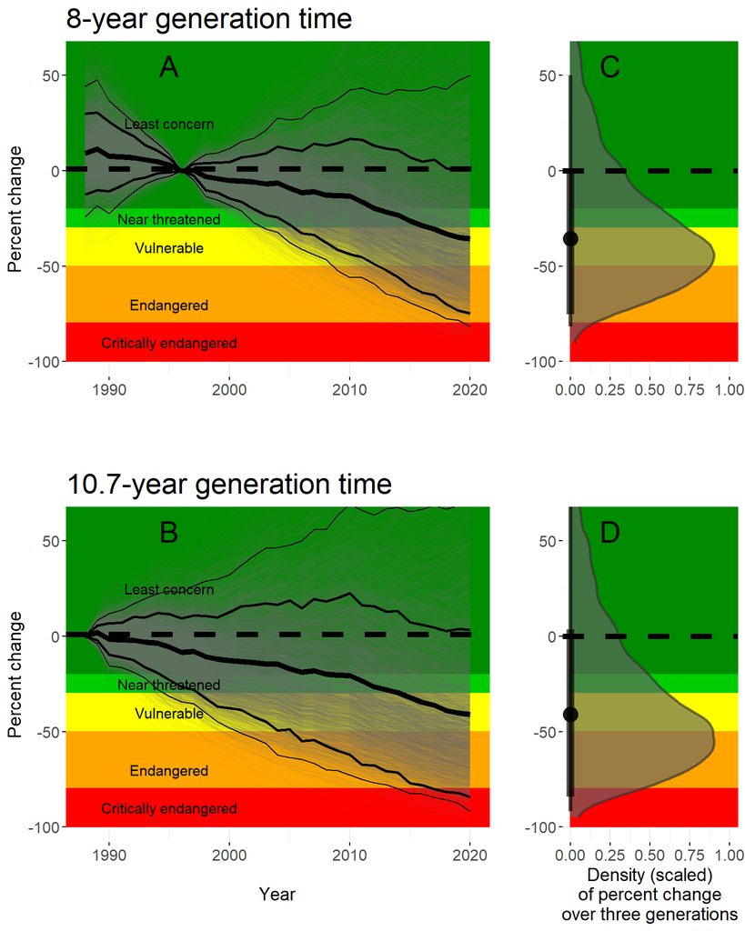

Fig. S7. Percent change in abundance of Snowy Owl.

```r
p56
```

```r
# ggsave(filename="C:\\Users\\rolek.brian\\OneDrive - The Peregrine Fund\\Documents\\Projects\\SnowyOwl_HawkMountain\\docs\\figs\\percentchange_year2.tiff",
#        plot=p56,
#        device="tiff",
#        width=8,
#        height=8,
#        dpi=300)

# calculate proportion of distribution in each category and mode
cuttab <- table(cut(iucn2020$value, breaks=c(-100,-80, -50, -30, -20, 300)))
prop <- cuttab/sum(cuttab)

df.iucn <- data.frame(IUCN.criteria=rev( c('Least concern', 'Near threatened', 'Vulnerable', 'Endangered', 'Critically endangered')),
                      Proportion.within=prop,
                      Proportion.within.and.worse= cumsum(prop)
)
df.iucn <- df.iucn[nrow(df.iucn):1,]
knitr::kable(df.iucn, digits=c(0, 0, 2, 2),
             row.names=FALSE,
             col.names = c("IUCN Category", "A2 Criteria", "Prop within", "Prop within and worse"),
             caption="Table S6. Percent change over three generations.")
```

Table S6. Percent change over three generations.

| IUCN Category | A2 Criteria | Prop within | Prop within and worse |
| --- | --- | --- | --- |
| Least concern | (-20,300] | 0.31 | 1.00 |
| Near threatened | (-30,-20] | 0.08 | 0.69 |
| Vulnerable | (-50,-30] | 0.23 | 0.61 |
| Endangered | (-80,-50] | 0.34 | 0.38 |
| Critically endangered | (-100,-80] | 0.04 | 0.04 |

```r
# write.csv(df.iucn,
#           "C:\\Users\\rolek.brian\\OneDrive - The Peregrine Fund\\Documents\\Projects\\SnowyOwl_HawkMountain\\docs\\IUCN2.csv")

# calculate the mode
dens <- density(iucn2020$value)
# mode
dens$x[dens$y==max(dens$y)]
```

```
## [1] -53.66316
```

```r
# median
median(iucn2020$value)
```

```
## [1] -40.95308
```

```r
# mean
mean(iucn2020$value)
```

```
## [1] -27.24941
```

## 2.3 Similar analysis including sites with shorter time series and site as a random effect

We tested whether a model including a random factor for site (N=9). This analysis includes sites with less abundance and shorter time series that were found to be less reliable in simulations.

### 2.3.1 Load packages and manipulate data

```r
library(readxl)
library(reshape2)
library(MCMCvis)
library(HDInterval)
library(ggplot2)
library(tidybayes)
library(bayestestR)
library(cowplot)
dat <- read.csv("data\\data.csv", na.strings="NA")
# change Bylot Island into
# 2 separate sites
# one of 100 km^2 and
# one of 300 km^2
dat$BylotIsland_300 <- dat$BylotIsland_400-dat$BylotIsland_100
colSums(!is.na(dat))
```

```
##                    year           Utqiagvik_213         BylotIsland_100
##                      35                      29                      28
##         BylotIsland_400     Igloolik.Island_114      Karupelv.Valley_75
##                      20                      10                      33
## Hochstetter.Forland_100          Fennoscandia_x                  Alaska
##                      11                      13                      32
##                 Wrangel         BylotIsland_300
##                      20                      20
```

```r
# Bundle data
y <- as.data.frame(dat[-c(1,2), -c(4)])

# create data lists for nimble
y.nim <- y[,-1]
datl <- list(y = y.nim) # exclude 8-fennoscania because no area information
constl <- list(nsite = ncol(y.nim),
               ntime = nrow(y.nim),
               time = (y$year-2004)/16
)
```

### 2.3.2 Run the model

This model includes data from all 9 sites and has a random effect for both site and time.

```r
#***********************
#* Negative binomial model
#* Best fitting model
#* having site and time random effects
#* in Appendix 3
#***********************
run <- function(seed, datl, constl){
  library('nimble')
  library('coda')
  library ('nimbleHMC')
  code <- nimbleCode(
    {
      # priors
      mu ~ dnorm(0, sd=5) # constrain to reasonable values <exp(5) or <148
      beta ~ dnorm(0, sd=5)
      for (j in 1:nsite){
        r[j] ~ dexp(0.2)
      }
      sigma.time ~ dexp(2)
      sigma.site ~ dexp(2)
      # likelihood
      for (t in 1:ntime){
        for (j in 1:nsite){
          p[t,j] <- r[j]/(r[j]+lambda[t,j])
          y[t,j] ~ dnegbin(p[t,j], r[j])
          # abundance
          log(lambda[t,j]) <- mu +
            beta*time[t] +
            eps.time[t] + eps.site[j]
        } # j
        eps.time[t] ~ dnorm(0, sd=sigma.time)
      } # t
      for (j in 1:nsite){ eps.site[j] ~ dnorm(0, sigma.site) }
      ###################
      # Assess GOF of the models for counts
      # Step 1: Compute statistic for observed data
      # Step 2: Use discrepancy measure: mean absolute error
      # Step 3: Use test statistic: number of turns
      ###################
      # GOF for model
      for (t in 1:ntime){
        for (j in 1:nsite){
          c.obs[t,j] <- y[t,j] # observed counts
          c.exp[t,j] <- lambda[t,j] # expected counts adult breeder
          c.rep[t,j] ~ dnegbin(p[t,j],r[j]) # expected counts
          # Compute fit statistics, Mean absolute error
          dssm.obs[t,j] <- abs( ( (c.obs[t,j]) - (c.exp[t,j]) ) / (c.obs[t,j]+0.001) )
          dssm.rep[t,j] <- abs( ( (c.rep[t,j]) - (c.exp[t,j]) ) / (c.rep[t,j]+0.001) )
        } } # j # t
      dmape.obs <- sum(dssm.obs[1:ntime,1:nsite])
      dmape.rep <- sum(dssm.rep[1:ntime,1:nsite])
      # variance-mean ratio
      tvm.rep <- sd(c.rep[1:ntime,1:nsite])^2/mean(c.rep[1:ntime,1:nsite])
      tvm.obs <- sd(y[1:ntime,1:nsite])^2/mean(y[1:ntime,1:nsite])
    }
  ) # end model

  params <- c(    "sigma.time", "sigma.site",
                  "mu", "beta", "r", "p",
                  "dssm.obs", "dssm.rep",
                  "dmape.obs", "dmape.rep",
                  "tvm.rep", "tvm.obs"
  )

  # create initial values for missing y data
  y.inits <- array(NA, dim(datl$y))
  y.inits[is.na(datl$y)] <- rpois(sum(is.na(datl$y)), 2)
  inits <- function(){ list (y = y.inits,
                             sigma.time = rexp(1),
                             sigma.site = rexp(1),
                             mu = runif(1, -2, 2),
                             beta = runif(1, -2, 2),
                             r = runif(constl$nsite)
  )}
  n.chains=1; n.thin=10; n.iter=20000; n.burnin=10000

  mod <- nimbleModel(code, calculate=T, constants = constl,
                     data = datl, inits = inits(),
                     buildDerivs = TRUE)

  mod$calculate()

  cmod <- compileNimble(mod )

  confhmc <- configureHMC(mod)
  confhmc$setMonitors(params)
  hmc <- buildMCMC(confhmc)
  chmc <- compileNimble(hmc, project=mod, resetFunctions = TRUE)

  post <- runMCMC(chmc,
                  niter = n.iter,
                  nburnin = n.burnin,
                  nchains = n.chains,
                  thin = n.thin,
                  samplesAsCodaMCMC = T)

  return(post)
}

# approximately 15 minute runtime
this_cluster <- makeCluster(4)
post <- parLapply(cl = this_cluster,
                  X = 1:4,
                  fun = run,
                  dat=datl,
                  const=constl)
stopCluster(this_cluster)

nb <- list(as.mcmc(post[[1]]),
           as.mcmc(post[[2]]),
           as.mcmc(post[[3]]),
           as.mcmc(post[[4]]))

# save(out=nb, post=post, run,
#      file="C:\\Users\\rolek.brian\\OneDrive - The Peregrine Fund\\Documents\\Projects\\SnowyOwl_HawkMountain\\nb_site-re_allsites.Rdata")
```

### 2.3.3 Postprocess and plot population growth

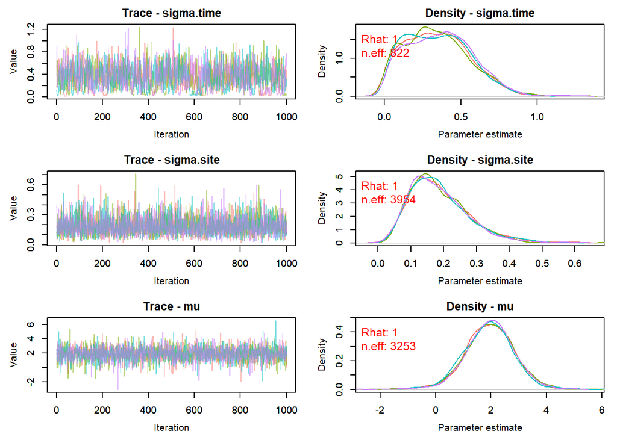

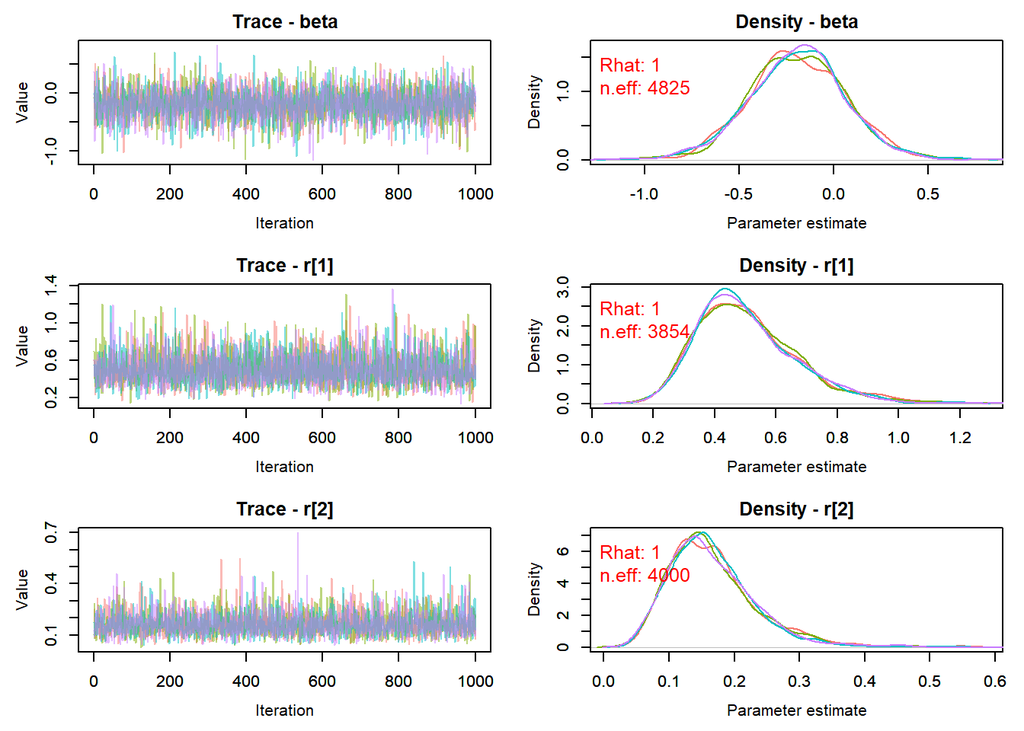

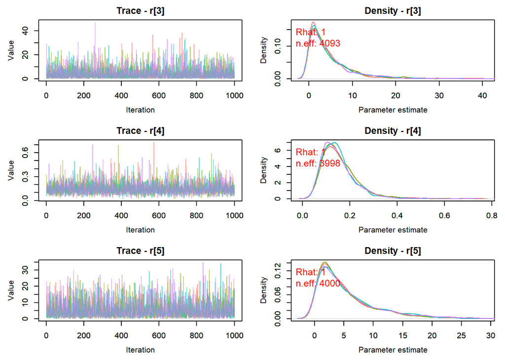

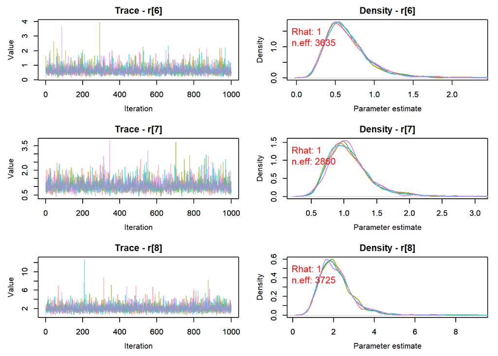

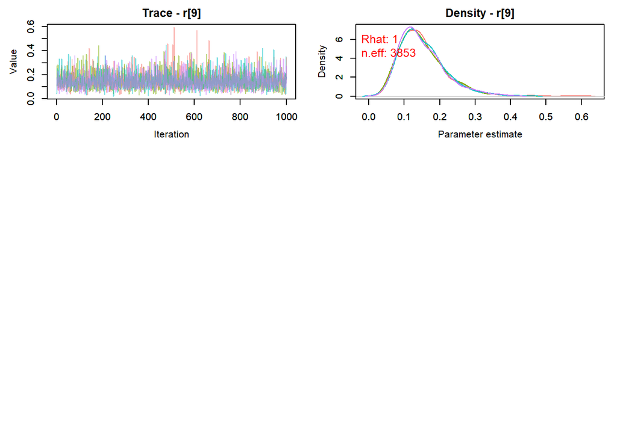

```r
load("C:\\Users\\rolek.brian\\OneDrive - The Peregrine Fund\\Documents\\Projects\\SnowyOwl_HawkMountain\\nb_site-re_allsites.Rdata")
# Check for convergence
params_nb <-c( "sigma.time", "sigma.site",
               "mu", "beta", "r")
MCMCtrace(nb, params_nb, pdf=F,
          ind = TRUE, Rhat = TRUE, n.eff = TRUE)
```

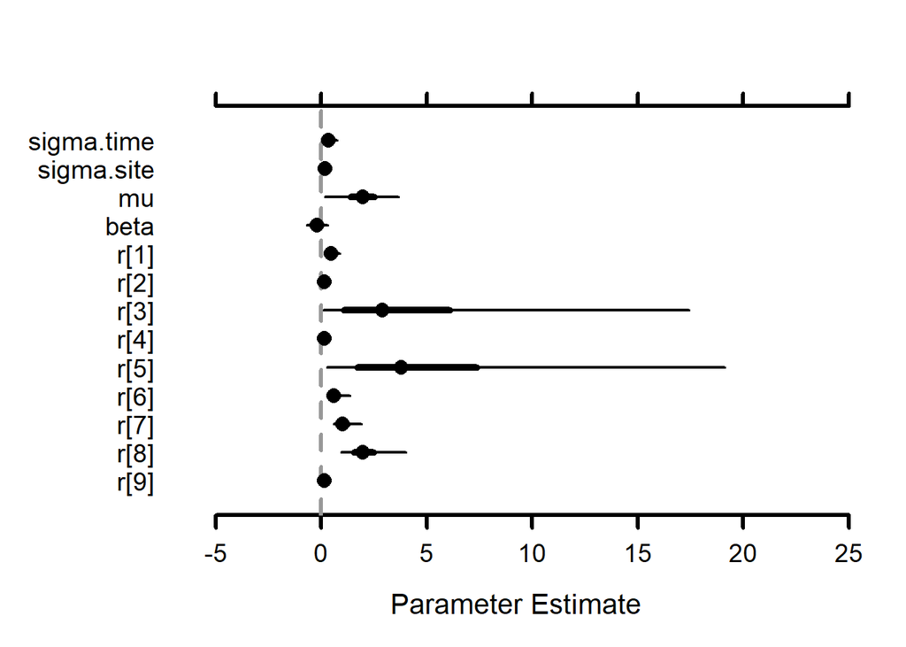

```r
par(mfrow=c(1,1))
MCMCplot(object = nb, params = params_nb)
```

```r
coeftab95 <- MCMCsummary(nb, params_nb,
                       HPD=TRUE,  hpd_prob = 0.95,
                       round=2, pg0 = TRUE, func = median,
                       func_name = "Median")
coeftab85 <- MCMCsummary(nb, params_nb,
                       HPD=TRUE,  hpd_prob = 0.85,
                       round=2, pg0 = TRUE, func = median,
                       func_name = "Median")

mu <- MCMCpstr(nb, "mu", type="chains")[[1]]
beta <- MCMCpstr(nb, "beta", type="chains")[[1]]
pred.lam <- array(NA, dim=c(length(constl$time), ncol(mu)))
for (t in 1:length(constl$time)){
  pred.lam[t,] <- mu +
    beta[1,]*constl$time[t]
}

lam.post <- array (NA, dim(pred.lam), dimnames=list(Year=1988:2020, Iter=1:4000))
# calculate lambda (population growth rate)
for (t in 2:nrow(pred.lam)){
    lam.post[t,] <- exp(pred.lam[t,]) / exp(pred.lam[t-1,])
  }
lam.post.long <- melt(lam.post)

# calculate overall average pop growth rate
av.post <- apply(lam.post, 2, mean, na.rm=T)
median(av.post, na.rm=T)
```

```
## [1] 0.9883551
```

```r
HDInterval::hdi(av.post, credMass = 0.95, na.rm=T)
```

```
##     lower     upper
## 0.9567679 1.0178284
## attr(,"credMass")
## [1] 0.95
```

```r
HDInterval::hdi(av.post, credMass = 0.80, na.rm=T)
```

```
##     lower     upper
## 0.9695829 1.0084350
## attr(,"credMass")
## [1] 0.8
```

```r
pd(av.post, null=1, na.rm=T)
```

```
## Probability of Direction: 0.79
```

```r
# calculate pop growth rates for each year
lam.df <- data.frame(
  year= 1988:2020,
  m= apply(lam.post, 1, median, na.rm=T),
  lci= apply(lam.post, 1, HDInterval::hdi)[1,],
  uci= apply(lam.post, 1, HDInterval::hdi)[2,],
  lci80 = apply(lam.post, 1, HDInterval::hdi, credMass=.8)[1,],
  uci80 = apply(lam.post, 1, HDInterval::hdi, credMass=.8)[2,],
  pd = apply(lam.post, 1, pd, null=1)
)

makeTransparent<-function(someColor, alpha=100){
  newColor<-col2rgb(someColor)
  apply(newColor, 2, function(curcoldata){rgb(red=curcoldata[1], green=curcoldata[2],
                                              blue=curcoldata[3],alpha=alpha, maxColorValue=255)})
}
c3 <- makeTransparent("gray40", alpha=10)
c4 <- makeTransparent(4, alpha=180)

rownames(datl$y) <- 1988:2020
names(dimnames(datl$y)) <- c("Year", "Site")
all.df <- melt(as.matrix(datl$y), value.name="Count")
colnames(all.df) <- c("Year", "Site", "Count")
labels <- unique(all.df$Site)

sl <- all.df[!is.na(all.df$Count),]

p1 <- ggplot()  + theme_minimal() +
  coord_cartesian(clip = "off") +
  geom_line(data=all.df,aes(x=Year,y=Site),linewidth=2, color='gray60')+
  geom_point(data=sl,aes(x=Year,y=Site),shape="I",size=4)+
  xlab("Year")+ylab("Site")+scale_color_viridis_c()+
  scale_y_discrete(labels=labels)+
  labs(color='black') +
  xlim(1988, 2020) + #theme(legend.position = "top") +
  annotate(geom = "text", x = 1990, y = 9.5, label = "A", size=6)

p2 <- ggplot() + theme_minimal() +
  geom_line(data=lam.post.long, aes(x=Year, y=value, group=Iter),
            color="gray40", linewidth=0.5, alpha=0.05 ) +
  geom_hline(yintercept=1, lwd=2, color="black", linetype="dashed") +
  geom_line(data=lam.df, aes(x=year, y=lci), color="deepskyblue3", linewidth=0.5 ) +
  geom_line(data=lam.df, aes(x=year, y=uci ), color="deepskyblue3", linewidth=0.5) +
  geom_line(data=lam.df, aes(x=year, y=lci80), color="deepskyblue3", linewidth=1 ) +
  geom_line(data=lam.df, aes(x=year, y=uci80), color="deepskyblue3", linewidth=1 ) +
  geom_line(data=lam.df, aes(x=year, y=m), color="deepskyblue3", linewidth=2 ) +
  xlab("Year") +
  ylab( expression(paste("Population growth (", lambda,")")) )+
  xlim(1988, 2020) +
  annotate(geom = "text", x = 1990, y = 1.1, label = "B", size=6)+
  coord_cartesian(xlim=c(1988, 2020), ylim=c(0.85, 1.15))

ap12 <- align_plots(p1, p2, align="v", axis="l")
p12 <- plot_grid(ap12[[1]], ap12[[2]], nrow = 2, align="v")
```

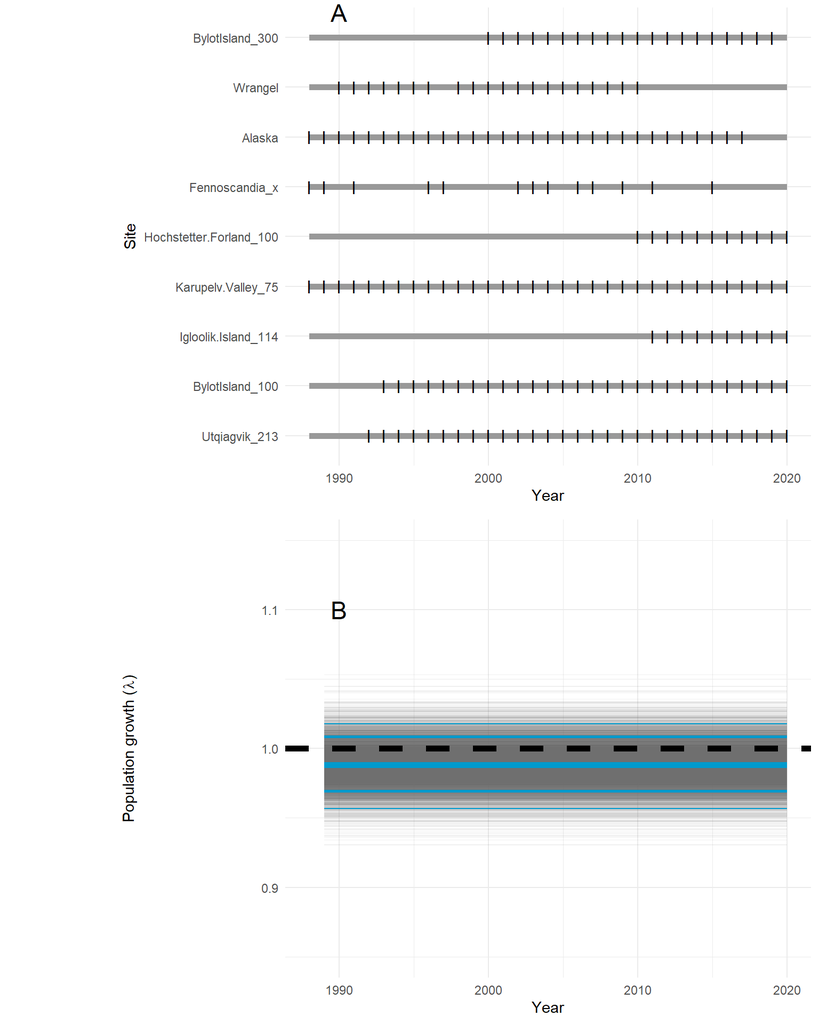

Fig. S8. Population growth rates of Snowy Owl using all data and a random effect for site.

```r
p12
```

```r
# ggsave(filename="C:\\Users\\rolek.brian\\OneDrive - The Peregrine Fund\\Documents\\Projects\\SnowyOwl_HawkMountain\\docs\\figs\\pop-growth-rate_year-siteRE.tiff",
#        plot=p12,
#        device="tiff",
#        width=6,
#        height=8,
#        dpi=300)
```

### 2.3.4 Postprocess and plot IUCN Criteria as percent change

```r
# plot percent change
perc.post <- array(NA, dim=dim(pred.lam), dimnames=list(Year=1988:2020, Iter=1:4000))
# calc lambda for each site relative to 1996
for (t in 1:nrow(pred.lam)){
  perc.post[t,] <- exp(pred.lam[t,]) / exp(pred.lam[9,])
}
perc.post.long <- melt(perc.post)
iucn <- (perc.post-1) * 100
iucn.post <- melt(iucn)

i.df <- data.frame(
  year = 1988:2020,
  m = apply(iucn, 1, median, na.rm=T),
  lci95 = apply(iucn, 1, HDInterval::hdi)[1,],
  uci95 = apply(iucn, 1, HDInterval::hdi)[2,],
  lci80 = apply(iucn, 1, HDInterval::hdi, credMass=0.8)[1,],
  uci80 = apply(iucn, 1, HDInterval::hdi, credMass=0.8)[2,],
  pd = apply(iucn, 1, pd)
)

knitr::kable(i.df, digits=c(0,1,1,1,1,1,2),
             row.names=FALSE,
             col.names = c("Year", "Median", "95% Lower HDI", "95% Upper HDI",
                           "85% Lower HDI", "85% Upper HDI", "Prob. direction"),
             caption="Table S7. Percent change since 1996.")
```

Table S7. Percent change since 1996.

| Year | Median | 95% Lower HDI | 95% Upper HDI | 85% Lower HDI | 85% Upper HDI | Prob. direction |
| --- | --- | --- | --- | --- | --- | --- |
| 1988 | 9.8 | -15.3 | 39.3 | -7.7 | 26.8 | 0.79 |
| 1989 | 8.5 | -13.5 | 33.7 | -5.7 | 24.1 | 0.79 |
| 1990 | 7.3 | -11.7 | 28.2 | -4.9 | 20.4 | 0.79 |
| 1991 | 6.0 | -9.9 | 23.0 | -4.1 | 16.7 | 0.79 |
| 1992 | 4.8 | -8.0 | 18.0 | -3.3 | 13.2 | 0.79 |
| 1993 | 3.6 | -5.9 | 13.4 | -2.5 | 9.7 | 0.79 |
| 1994 | 2.4 | -3.9 | 8.8 | -1.7 | 6.4 | 0.79 |
| 1995 | 1.2 | -1.8 | 4.5 | -0.8 | 3.1 | 0.79 |
| 1996 | 0.0 | 0.0 | 0.0 | 0.0 | 0.0 | 0.00 |
| 1997 | -1.2 | -4.3 | 1.8 | -3.0 | 0.8 | 0.79 |
| 1998 | -2.3 | -8.5 | 3.6 | -6.0 | 1.7 | 0.79 |
| 1999 | -3.5 | -12.4 | 5.4 | -9.1 | 2.3 | 0.79 |
| 2000 | -4.6 | -16.2 | 7.3 | -12.0 | 3.0 | 0.79 |
| 2001 | -5.7 | -19.8 | 9.2 | -14.7 | 3.8 | 0.79 |
| 2002 | -6.8 | -23.3 | 11.2 | -18.1 | 3.8 | 0.79 |
| 2003 | -7.9 | -26.6 | 13.2 | -20.8 | 4.5 | 0.79 |
| 2004 | -8.9 | -30.6 | 14.4 | -23.4 | 5.1 | 0.79 |
| 2005 | -10.0 | -33.7 | 16.3 | -26.9 | 4.8 | 0.79 |
| 2006 | -11.1 | -36.6 | 18.3 | -29.4 | 5.4 | 0.79 |
| 2007 | -12.1 | -39.4 | 20.3 | -31.8 | 5.9 | 0.79 |
| 2008 | -13.1 | -42.1 | 22.3 | -34.1 | 6.5 | 0.79 |
| 2009 | -14.1 | -44.7 | 24.4 | -36.6 | 6.8 | 0.79 |
| 2010 | -15.1 | -47.2 | 26.5 | -40.5 | 5.7 | 0.79 |
| 2011 | -16.1 | -49.5 | 28.7 | -42.6 | 6.1 | 0.79 |
| 2012 | -17.1 | -51.8 | 30.8 | -44.7 | 6.5 | 0.79 |
| 2013 | -18.1 | -57.8 | 29.1 | -46.7 | 6.9 | 0.79 |
| 2014 | -19.0 | -59.9 | 31.1 | -48.7 | 7.3 | 0.79 |
| 2015 | -20.0 | -61.8 | 33.0 | -50.5 | 7.8 | 0.79 |
| 2016 | -20.9 | -63.7 | 35.1 | -53.3 | 7.2 | 0.79 |
| 2017 | -21.8 | -65.5 | 37.1 | -55.1 | 7.6 | 0.79 |
| 2018 | -22.7 | -67.2 | 39.2 | -56.7 | 7.9 | 0.79 |
| 2019 | -23.6 | -68.8 | 41.3 | -58.4 | 8.3 | 0.79 |
| 2020 | -24.5 | -70.4 | 43.4 | -59.9 | 8.7 | 0.79 |

```r
p3 <- ggplot() + theme_minimal() +
  geom_rect(aes(xmin=1986, xmax=2022, ymin=-20, ymax=300), color="green4", fill="green4") +
  geom_rect(aes(xmin=1986, xmax=2022, ymin=-30, ymax=-20), color="green3", fill="green3") +
  geom_rect(aes(xmin=1986, xmax=2022, ymin=-50, ymax=-30), color="yellow", fill="yellow") +
  geom_rect(aes(xmin=1986, xmax=2022, ymin=-80, ymax=-50), color="orange", fill="orange") +
  geom_rect(aes(xmin=1986, xmax=2022, ymin=-100, ymax=-80), color="red", fill="red") +
  geom_line(data=iucn.post, aes(x=Year, y=value, group=Iter),
            color="gray40", size=0.5, alpha=0.05 ) +
  geom_hline(yintercept=1, lwd=2, color="black", linetype="dashed") +
  geom_line(data=i.df, aes(x=year, y=lci95), color="black", size=0.5 ) +
  geom_line(data=i.df, aes(x=year, y=uci95 ), color="black", size=0.5) +
  geom_line(data=i.df, aes(x=year, y=lci80), color="black", size=1 ) +
  geom_line(data=i.df, aes(x=year, y=uci80), color="black", size=1 ) +
  geom_line(data=i.df, aes(x=year, y=m), color="black", size=2 ) +
  annotate(geom = "text", x = 1995, y = 25, label = "Least concern", size=4, color="black") +
  annotate(geom = "text", x = 1995, y = -25, label = "Near threatened", size=4, color="black") +
  annotate(geom = "text", x = 1995, y = -40, label = "Vulnerable", size=4, color="black") +
  annotate(geom = "text", x = 1995, y = -70, label = "Endangered", size=4, color="black") +
  annotate(geom = "text", x = 1995, y = -90, label = "Critically endangered", size=4, color="black") +
  xlab("Year") +
  ylab( "Percent change")+
  coord_cartesian(xlim=c(1988, 2020), ylim=c(-100, 60)) +
  annotate(geom = "text", x = 1995, y = 55, label = "A", size=8) +
  theme(axis.text= element_text(size=12),
        axis.title=element_text(size=14),
        axis.ticks = element_line(color = "black"))

iucn2020 <- iucn.post[iucn.post$Year==2020, ]
i.df2020 <- i.df[i.df$year==2020,]

p4 <- ggplot() + theme_minimal() +
  geom_rect(aes(ymin=0, ymax=2, xmin=-20, xmax=300), color="green4", fill="green4") +
  geom_rect(aes(ymin=0, ymax=2, xmin=-30, xmax=-20), color="green3", fill="green3") +
  geom_rect(aes(ymin=0, ymax=2, xmin=-50, xmax=-30), color="yellow", fill="yellow") +
  geom_rect(aes(ymin=0, ymax=2, xmin=-80, xmax=-50), color="orange", fill="orange") +
  geom_rect(aes(ymin=0, ymax=2, xmin=-100, xmax=-80), color="red", fill="red") +
  stat_halfeye(data=iucn2020, aes(x = value, y=0), alpha=0.65,
               slab_color="gray20", slab_fill="gray40",
               point_interval="median_hdi", .width = c(0.80, 0.95),
               point_size=5) +
  scale_size_continuous(range = c(7, 15)) +
  geom_vline(xintercept=0, lwd=2, color="black", linetype="dashed") +
  xlab("") + ylab("Density (scaled)\nof percent change\nover three generations") +
  annotate(geom = "text", x = 55, y = 0.25, label = "B", size=8) +
  theme(axis.text= element_text(size=12),
        axis.title=element_text(size=14),
        axis.ticks = element_line(color = "black")) +
  coord_flip(xlim=c(-100, 60), ylim=c(0, 1), clip="on")

ap45 <- align_plots(p3, p4, align="h", axis="l")
p45 <- plot_grid(ap45[[1]], ap45[[2]], nrow = 1, align="h", rel_widths = c(2, 1))
```

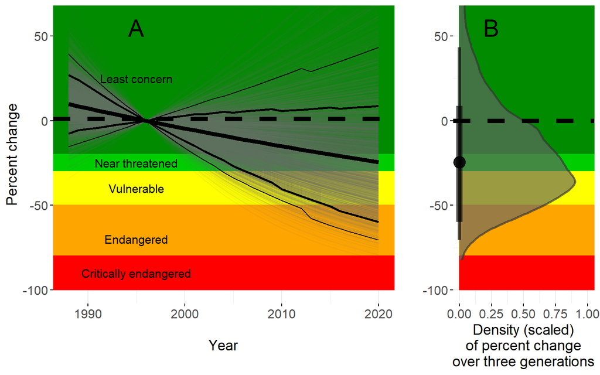

Fig. S9. Percent change in abundance of Snowy Owl since 1996 using all data and a random effect for site.

```r
p45
```

```r
# ggsave(filename="C:\\Users\\rolek.brian\\OneDrive - The Peregrine Fund\\Documents\\Projects\\SnowyOwl_HawkMountain\\docs\\figs\\percentchange_year-resites.tiff",
#        plot=p45,
#        device="tiff",
#        width=8,
#        height=4,
#        dpi=300)
```